## **Numbat**

### Blamed on cats

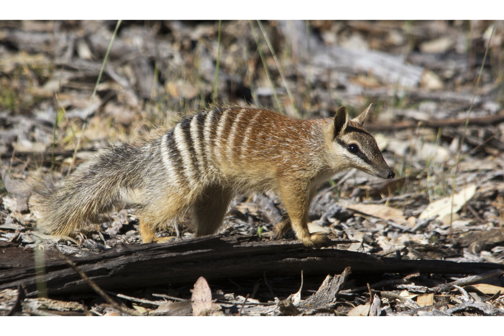

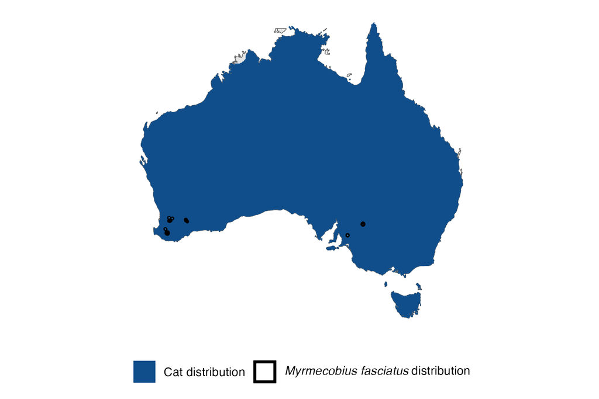

IUCN status: **Endangered**

EPBC Predator Threat Rating: **Very high**

IUCN claim: *“The introduction of the predatory Red Fox and feral cats has had a profound impact and continues to be a major threat today (Friend 2008).”*

### Studies not in support

Numbats were last confirmed in Adelaide 4 years before, to 6 years after, cats arrived (Wallach and Lundgren 2025).

### Is the threat claim evidence-based?

No studies were found linking cats to numbat population trends. In one region it cannot be verified that extirpation occurred after cat arrival, and the two species possibly co-occurred for over a century across the Wheatbelt, WA.

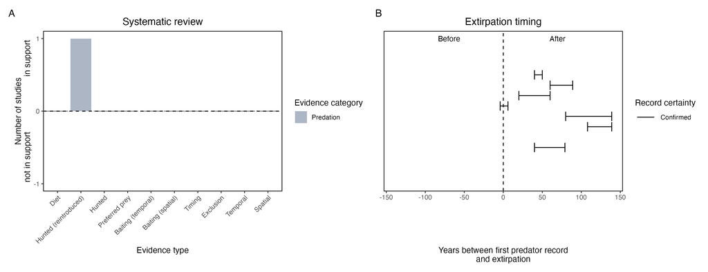

**Evidence linking *Myrmecobius fasciatus* to cats.** **A.** Systematic review of evidence for an association between *Myrmecobius fasciatus* and cats. Positive studies are in support of the hypothesis that cats contribute to the decline of *Myrmecobius fasciatus*, negative studies are not in support. Predation studies include studies documenting hunting or scavenging; baiting studies are associations between poison baiting and threatened mammal abundance where information on predator abundance is not provided; population studies are associations between threatened mammal and predator abundance. Gold borders indicate studies that meet qualities of scientific rigour. **B.** Last records of extirpated populations relative to earliest local records of cats. Error bars show minimum and maximum extinction intervals. Predator arrival records were digitized from Abbott 2008. See methods section in Wallach and Lundgren 2025 for details on evidence categories.

### References

Abbott, The spread of the cat, Felis catus, in Australia: re-examination of the current conceptual model with additional information. Conservation Science Western Australia 7 (2008).

EPBC. (2015) Threat Abatement Plan for Predation by Feral Cats. Environment Protection and Biodiversity Conservation Act 1999, Department of Environment, Government of Australia. (Table A1).

Friend, J.A. and Thomas, N.D., 1994. Reintroduction and the numbat recovery programme. Reintroduction Biology of Australian and New Zealand Fauna’.(Ed. M. Serena.) pp, pp.189-198.

IUCN Red List. https://www.iucnredlist.org/ Accessed June 2023

Wallach A.D., Lundgren E.J. (2025) Review of evidence that foxes and cats cause extinctions of Australia’s endemic mammals. BioScience. DOI: 10.1093/biosci/biaf046